# Differential binding analysis with diffbind

David Lewis

# Introduction

- What is ChIP-seq data?
- How is Diffbind used?
- What do we get from Diffbind?

# What is ChIP-seq data?

- ChIP-seq: Chromatin Immunoprecipitation sequencing
- Determine protein binding to genome

# What is differential binding analysis?

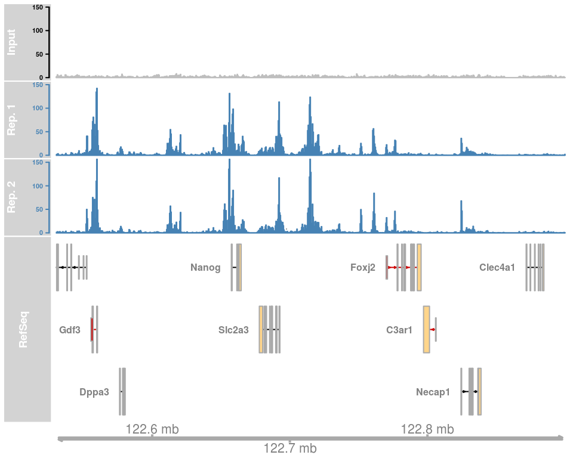

- Difference between the binding site in condition vs control
- Very similar to other differential analysis (differential expression analysis)

# Using Diffbind

### Downloading the sample data from the vignette

```r
url <- "https://content.cruk.cam.ac.uk/bioinformatics/software/DiffBind/DiffBind_vignette_data.tar.gz"
file <- basename(url)
options(timeout = 600)
download.file(url, file.path(".", file))
untar(file.path(".", file), exdir = ".")
```

### Examining the metadata

```r
head(read.csv("tamoxifen.csv"))[c("Condition", "bamReads")]
```

| Condition | bamReads |
| --- | --- |
| Resistant | reads/Chr18_BT474_ER_1.bam |
| Resistant | reads/Chr18_BT474_ER_2.bam |
| Responsive | reads/Chr18_MCF7_ER_1.bam |
| Responsive | reads/Chr18_MCF7_ER_2.bam |
| Responsive | reads/Chr18_MCF7_ER_3.bam |
| Responsive | reads/Chr18_T47D_ER_1.bam |

### Run the analysis

```r
tamoxifen <- DiffBind::dba.analyze("tamoxifen.csv")
```

```
## Loading sample sheet...
```

```
## BT4741 BT474 ER Resistant Full-Media 1 bed
```

```
## BT4742 BT474 ER Resistant Full-Media 2 bed
```

```
## MCF71 MCF7 ER Responsive Full-Media 1 bed
```

```
## MCF72 MCF7 ER Responsive Full-Media 2 bed
```

```
## MCF73 MCF7 ER Responsive Full-Media 3 bed
```

```
## T47D1 T47D ER Responsive Full-Media 1 bed
```

```
## T47D2 T47D ER Responsive Full-Media 2 bed
```

```
## MCF7r1 MCF7 ER Resistant Full-Media 1 bed
```

```
## MCF7r2 MCF7 ER Resistant Full-Media 2 bed
```

```
## ZR751 ZR75 ER Responsive Full-Media 1 bed
```

```
## ZR752 ZR75 ER Responsive Full-Media 2 bed
```

```
## Applying Blacklist/Greylists...
```

```
## Genome detected: Hsapiens.UCSC.hg19
```

```
## Applying blacklist...
```

```
## Removed: 3 of 14102 intervals.
```

```
## Counting control reads for greylist...
```

```
## Building greylist: reads/Chr18_BT474_input.bam
```

```
## coverage: 166912 bp (0.21%)
```

```
## Building greylist: reads/Chr18_MCF7_input.bam
```

```
## coverage: 106495 bp (0.14%)
```

```
## Building greylist: reads/Chr18_T47D_input.bam
```

```
## coverage: 57344 bp (0.07%)
```

```
## Building greylist: reads/Chr18_TAMR_input.bam
```

```
## coverage: 122879 bp (0.16%)
```

```
## Building greylist: reads/Chr18_ZR75_input.bam
```

```
## coverage: 72704 bp (0.09%)
```

```
## BT474c: 58 ranges, 166912 bases
```

```
## MCF7c: 14 ranges, 106495 bases
```

```
## T47Dc: 11 ranges, 57344 bases
```

```
## TAMRc: 10 ranges, 122879 bases
```

```
## ZR75c: 15 ranges, 72704 bases
```

```
## Master greylist: 72 ranges, 255487 bases
```

```
## Removed: 420 of 14099 intervals.
```

```
## Removed: 52 merged (of 3795) and 50 (of 2845) consensus.
```

```
## Forming consensus peakset and counting reads...
```

```
## Computing summits...
```

```
## Re-centering peaks...
```

```
## Normalize DESeq2 with defaults...
```

```
## Forming default model design and contrast(s)...
```

```
## Computing results names...
```

```
## Analyzing...
```

```r
DiffBind::dba.report(tamoxifen)
```

```
## GRanges object with 246 ranges and 6 metadata columns:
##        seqnames            ranges strand |      Conc Conc_Responsive
##           <Rle>         <IRanges>  <Rle> | <numeric>       <numeric>
##    943    chr18 26861047-26861447      * |   8.37281         8.98991
##   2422    chr18 65030123-65030523      * |   6.02482         6.62520
##   1449    chr18 41369550-41369950      * |   8.25529         8.84621
##   2404    chr18 64490736-64491136      * |   7.42827         8.05134
##   2290    chr18 60892950-60893350      * |   8.09133         8.72229
##    ...      ...               ...    ... .       ...             ...
##   1187    chr18 33021825-33022225      * |   5.04267         5.57838
##    408    chr18 11320959-11321359      * |   4.29417         3.38332
##   1945    chr18 53054738-53055138      * |   6.44506         5.53915
##    218    chr18   7757228-7757628      * |   5.04773         3.56723
##   1370    chr18 38482793-38483193      * |   4.23057         4.76394
##        Conc_Resistant      Fold     p-value         FDR
##             <numeric> <numeric>   <numeric>   <numeric>
##    943        4.44855   3.10593 1.95264e-08 3.58819e-05
##   2422        2.65613   2.87530 3.13216e-08 3.58819e-05
##   1449        5.12414   2.75925 4.18808e-08 3.58819e-05
##   2404        3.23712   3.09946 5.23823e-08 3.58819e-05
##   2290        3.44567   3.14110 8.21331e-08 4.50090e-05
##    ...            ...       ...         ...         ...
##   1187        2.81227   1.47761  0.00426958   0.0483415
##    408        5.15749  -1.31788  0.00433276   0.0488549
##   1945        7.30585  -1.28749  0.00438440   0.0492346
##    218        6.13374  -1.46288  0.00440236   0.0492346
##   1370        2.02778   1.47251  0.00443285   0.0493740
##   -------
##   seqinfo: 1 sequence from an unspecified genome; no seqlengths
```

```r
tamoxifen <- dba(sampleSheet = "tamoxifen.csv") %>%
    +dba.blacklist() %>%
    +dba.count() %>%
    +dba.normalize() %>%
    +dba.contrast() %>%
    +dba.analyze()
```

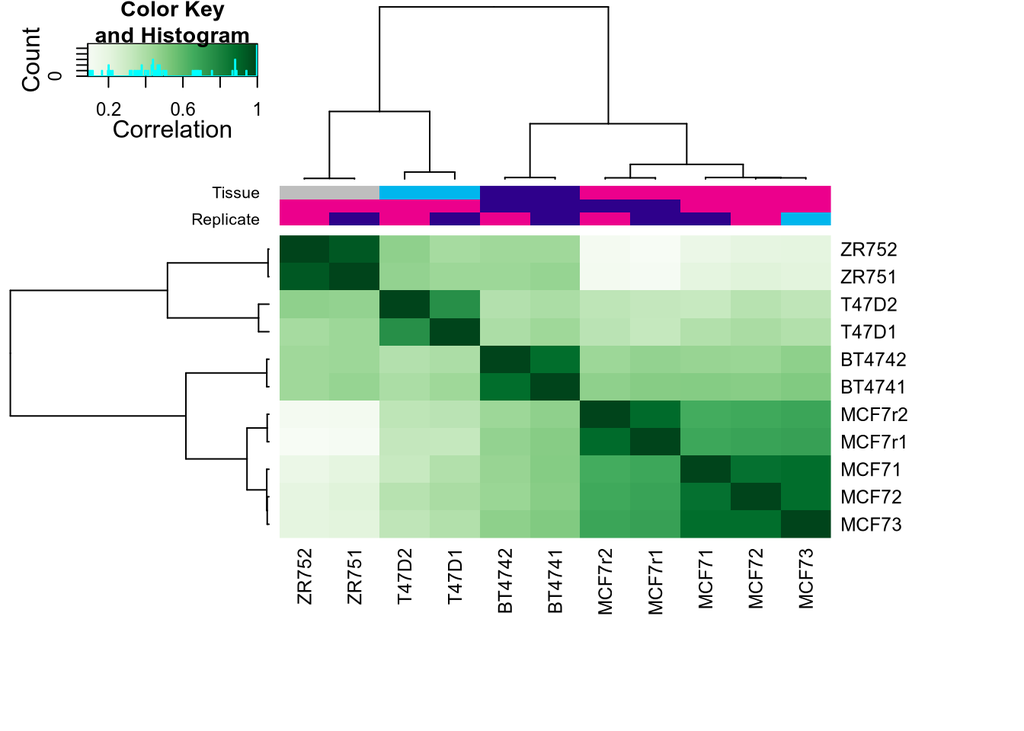

```r
plot(tamoxifen)
```

```r
DiffBind::dba.show(tamoxifen, bContrasts = TRUE)
```

| Factor | Group | Samples | Group2 | Samples2 | DB.DESeq2 |
| --- | --- | --- | --- | --- | --- |
| Condition | Responsive | 7 | Resistant | 4 | 246 |

Using only the 246 Genes.

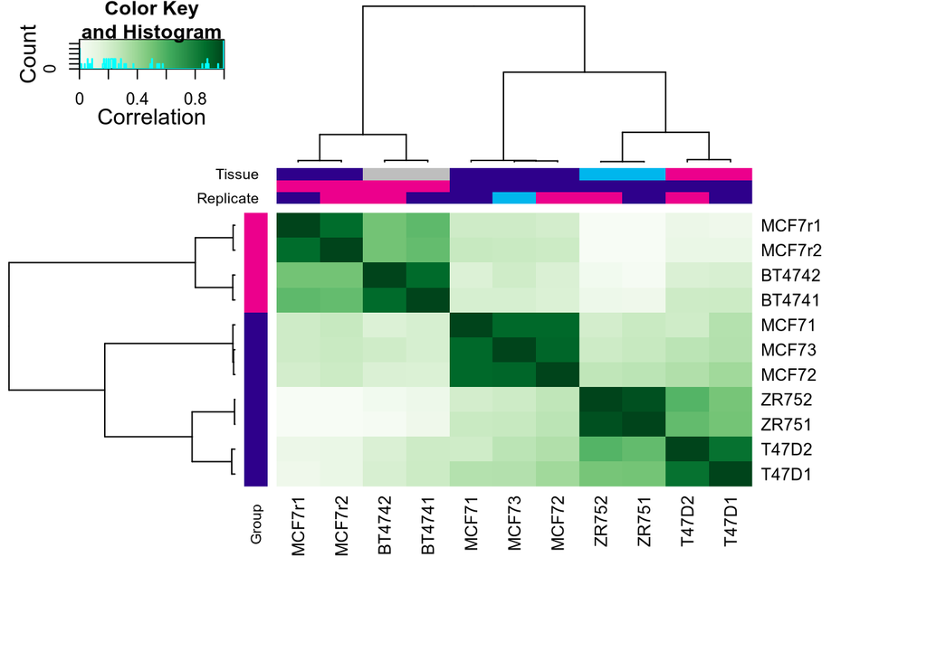

```r
plot(tamoxifen, contrast = 1)
```

# Plotting With DiffBind

```
## Generating report-based DBA object...
```

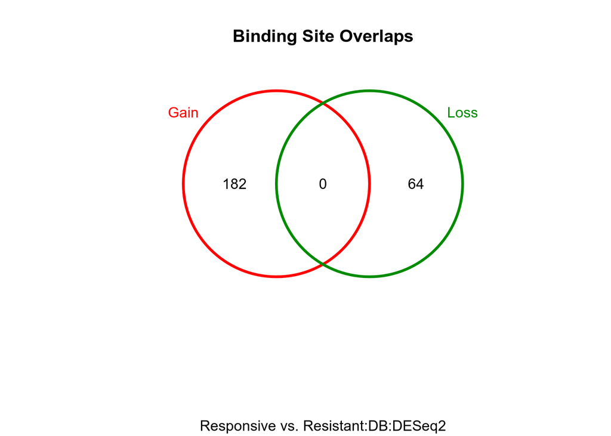

```r
DiffBind::dba.plotVenn(tamoxifen, contrast = 1, bDB = TRUE, bGain = TRUE, bLoss = TRUE, bAll = FALSE)
```

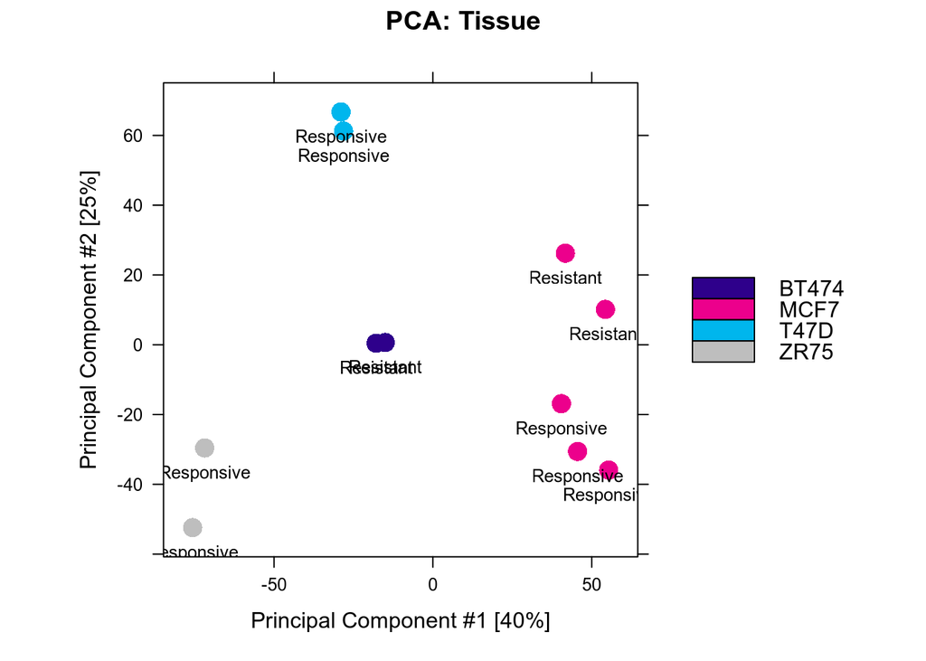

```r
DiffBind::dba.plotPCA(tamoxifen, DiffBind::DBA_TISSUE, label = DiffBind::DBA_CONDITION)
```

### MA Plot

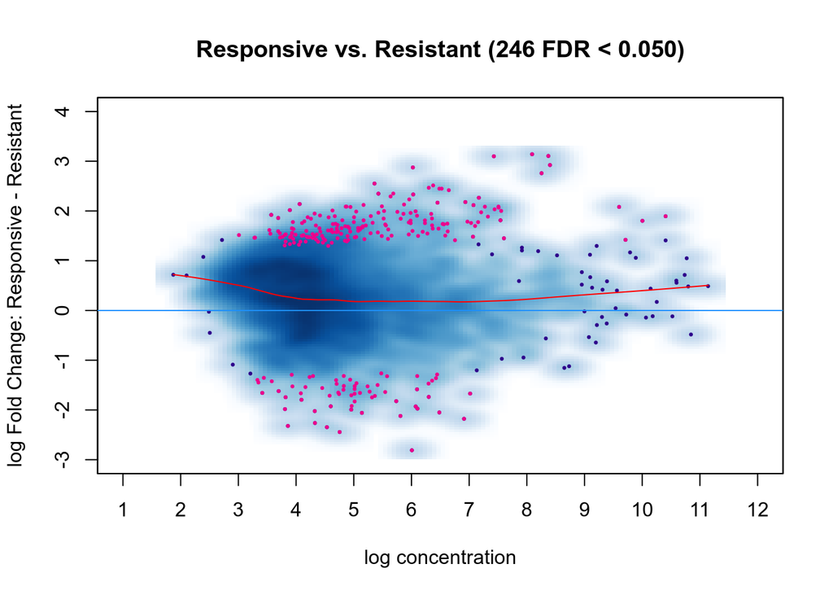

```r
DiffBind::dba.plotMA(tamoxifen)
```

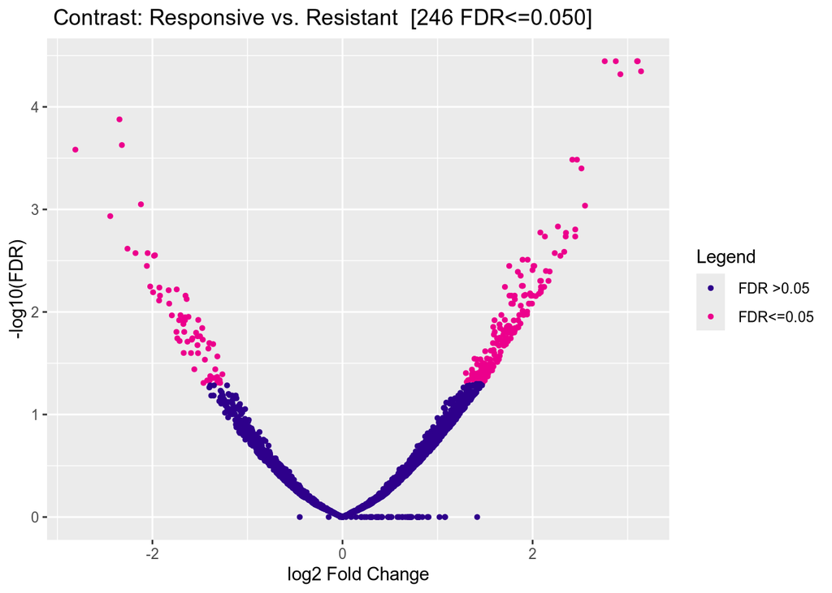

```r
DiffBind::dba.plotVolcano(tamoxifen)
```

# Deliverables

- Table of differentially bound regions of the genome (binding sites)
- Plots

# Under the hood

- Either Deseq2 or EdgeR is used for differential binding analysis
- These tools are usually used for differentially expression analysis

## Deseq2

- Fits a negative binomial distribution to the data
- Quantifies expected gene (or “read”) variance from mean
- Genes that defy this expectation are considered “significant”

# Conclusion

- What is ChIP-seq data?
- How is Diffbind used?
- What do we get from Diffbind?

Diffbind utilizes commonly used differential expression analysis tools to determine differentially bound sites on the genome.